# Assessment 3

Veronika Varaksina s4646146

10 11 2021

——————————– Introduction ——————————–

Disney+ is an American subscription video on-demand over-the-top streaming service owned and operated by the Media and Entertainment Distribution division of The Walt Disney Company. The upcoming analysis and insights will assist Disney+ marketing department to better position promotion for upcoming shows.

```r
movie <- read.csv("final_movie.csv")
disney <- read.csv("final_disney.csv")
```

—————————– Data Visualization —————————–

### Selecting only the important variables

```r
disney <- disney %>%
  mutate(text = as.character(text))

disney <- disney%>%
  select(user_id,created_at,screen_name,text,display_text_width,favorite_count,
         retweet_count,place_full_name)
```

### Top tweeting location

```r
movie %>%
  filter(!is.na(place_full_name)) %>%
  count(place_full_name, sort = TRUE) %>%
  top_n(10)
```

```
##     place_full_name  n
## 1   Los Angeles, CA 98
## 2      Brooklyn, NY 32
## 3       Chicago, IL 31
## 4      Franklin, TN 26
## 5       Houston, TX 24
## 6     Manhattan, NY 24
## 7       Atlanta, GA 22
## 8      Florida, USA 21
## 9  Philadelphia, PA 19
## 10       Austin, TX 18
## 11     Georgia, USA 18
## 12       Texas, USA 18
```

```r
disney %>%
  filter(!is.na(place_full_name)) %>%
  count(place_full_name, sort = TRUE) %>%
  top_n(10)
```

```
##      place_full_name   n
## 1       Florida, USA 271
## 2    Los Angeles, CA  73
## 3        Anaheim, CA  59
## 4      Illinois, USA  34
## 5        Chicago, IL  24
## 6      Manhattan, NY  21
## 7        Orlando, FL  21
## 8         Texas, USA  20
## 9        Houston, TX  18
## 10      Georgia, USA  17
## 11 San Francisco, CA  17
## 12  Toronto, Ontario  17
```

### Most liked tweet

```r
disney %>%
  arrange(-favorite_count) %>%
  top_n(5, favorite_count) %>%
  select(created_at, screen_name, text, favorite_count)
```

```
##             created_at screen_name
## 1 2021-10-23T20:23:14Z     LilNasX
## 2 2021-10-22T21:48:56Z         IGN
## 3 2021-10-23T20:07:58Z skaijackson
## 4 2021-10-26T21:30:40Z    realQuig
## 5 2021-10-31T16:46:18Z  gwendalupe
##                                                                                                                                                                                                                                                                 text
## 1                                                                                                               i am truly saddened. i have never been so mortified in my life. i canâ\200\231t believe disney channel has yet to play halloween town this entire october.
## 2 BREAKING: Hayden Christensen is set to reprise his role as Anakin Skywalker/Darth Vader in the upcoming Ahsoka Disney+ series. https://t.co/TFn3NEOx8j\n\nHe was previously confirmed to be involved in the Obi-Wan Kenobi series as well. https://t.co/w5Jk3AQ84B
## 3                                                                                                                                                      This is a tremendous loss for the Disney community. Mrs Kipling was so legendary ðŸ\230 https://t.co/osEf62qTYE
## 4                                                                                                                                                                                                          Ran into some streamers at Disney https://t.co/ZtiMGdKrLs
## 5                                                                                                                                                                                              halloween was such an event on disney channel https://t.co/taZUFv8Li6
##   favorite_count
## 1         168820
## 2          48107
## 3          35258
## 4          14741
## 5          13339
```

### Top hashtags

```r
disney %>%
  unnest_tokens(hashtag, text, "tweets", to_lower = FALSE) %>%
  filter(str_detect(hashtag, "^#"),
        hashtag != "#ClimateEmergency") %>%
  count(hashtag, sort = TRUE) %>%
  top_n(15)
```

```
##                 hashtag    n
## 1          #Sweepstakes 5646
## 2        #DisneyWorld50 3019
## 3               #Disney 2836
## 4          #Southwest50 2805
## 5               #disney 2576
## 6           #Disneyland 1714
## 7             #zonauang 1594
## 8          #DisneyParks 1509
## 9                  #DLR 1342
## 10                 #DCA 1341
## 11    #DisneylandResort 1325
## 12 #CaliforniaAdventure 1311
## 13         #MagicIsHere 1308
## 14              #zonaba 1111
## 15        #shopmycloset 1060
```

### Top mentions

```r
disney %>%
  unnest_tokens(mentions, text, "tweets", to_lower = FALSE) %>%
  filter(str_detect(mentions, "^@")) %>%
  count(mentions, sort = TRUE) %>%
  top_n(10)
```

```
##           mentions    n
## 1          @Disney 4476
## 2     @DisneyLiz15 1429
## 3     @blondjewels 1377
## 4  @ChuckyReforged 1116
## 5  @ArtistFKAGamer 1112
## 6     @AJEqualizer 1104
## 7     @KidCHAOS138 1104
## 8      @yesisworld 1104
## 9         @GoneAye 1087
## 10 @Pittsburgbitch 1055
```

### Movie genre

```r
genres <- disney %>%
  unnest_tokens(text, text, "tweets", to_lower = FALSE) %>%
  filter(str_detect(text, "(^horror|^animation|^comedy|^action| ^fantasy|^drama|^romantic)")) %>%
  count(text, sort = TRUE) %>%
  top_n(10)
```

—————————– Sentiment Analysis—————————–

### Bing sentiment analysis by the day of week

```r
disney <-
  disney %>%
  mutate(timestamp=ymd_hms(created_at),
    day_of_week=wday(timestamp),
    id=as_factor(row_number())
  )

disney <- disney %>%
  mutate(day_of_week = case_when(day_of_week == 1 ~ "Sunday",
                                 day_of_week == 2 ~ "Monday",
                                 day_of_week == 3 ~ "Tuesday",
                                 day_of_week == 4 ~ "Wednesday",
                                 day_of_week == 5 ~ "Thursday",
                                 day_of_week == 6 ~ "Friday",
                                 day_of_week == 7 ~ "Saturday")) %>%
  mutate(day_of_week = as.factor(day_of_week))

remove_reg <- "&amp;|&lt;|&gt;|\\d+\\w*\\d*|#\\w+|[^\x01-\x7F]|[[:punct:]]|https\\S*"

#removing retweets characters
tidy_disney <- disney %>%
  filter(!str_detect(text, "^RT")) %>%
  mutate(text = str_remove_all(text, remove_reg))

#unnesting tweets
tidy_disney <- tidy_disney %>%
  unnest_tokens(word, text, token = "tweets")
```

```
## Using `to_lower = TRUE` with `token = 'tweets'` may not preserve URLs.
```

```r
# Remove mentions, urls, emojis, numbers, punctuations, etc.
tidy_disney <- tidy_disney %>%
  filter(
    str_detect(word, "[a-z]")#keep only character-words
    )%>%
  anti_join((stop_words))
#sentiment
bing<-get_sentiments("bing")
nrc<-get_sentiments("nrc")

selected_disney <- tidy_disney %>% select(timestamp, day_of_week, word, user_id)

selected_disney <- selected_disney %>%
  inner_join(bing)%>%
  rename(sentiment_bing=sentiment)%>%
inner_join(nrc)%>%
  rename(sentiment_nrc=sentiment)
```

**Insight** The graph below showcases the sentiment analysis of disney+ tweets by each day of the week. Tweeter users tend to tweet more about disney plus on Sunday and Saturday, whereas the lowest amount of tweets is recorded on Wednesday. This is not a surprising statistics, since according to studies, people tend to “binge watch” TV shows on weekends, when the average watch hour is equal to 4, in comparison to 2 on weekdays. Disney+ future anticipated releases could be moved to weekends, when audience is more likely to finish the show in one sitting.

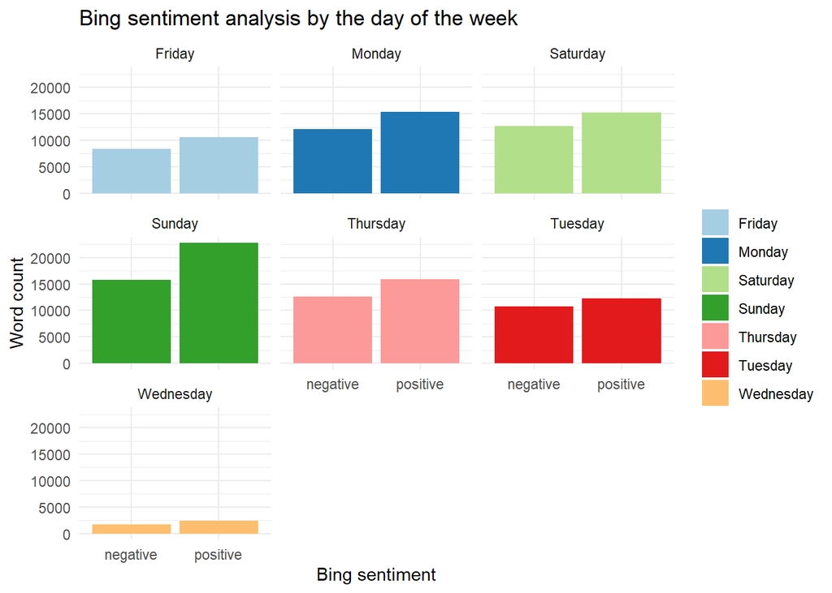

```r
selected_disney %>%
  ggplot(aes(sentiment_bing, fill = day_of_week)) +
  geom_bar() +
  facet_wrap( ~day_of_week) +
  theme_minimal() +
  scale_fill_brewer(palette = "Paired") +
  labs(title = "Bing sentiment analysis by the day of the week",
       x = "Bing sentiment",
       y = "Word count") +
  theme(legend.title = element_blank())
```

### Nrc sentiment analysis

**Insight** On average, people tend to use less angry and sad words when they tweet about disney+. top three positive emotions include joy anticipation and trust.

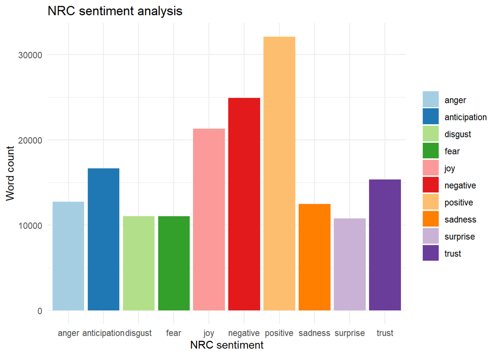

```r
selected_disney %>%
  ggplot(aes(sentiment_nrc, fill = sentiment_nrc)) +
  geom_bar() +
  theme_minimal() +
  labs(title = "NRC sentiment analysis",
       x = "NRC sentiment",
       y = "Word count") +
  theme(legend.title = element_blank()) +
  scale_fill_brewer(palette = "Paired")
```

### Most popular positive tweets

**Insight** In this case, marvel is classified as a positive word. However, tweeter users most likely are referring to a cinematic universe, that is owned by disney. Disney is the primary streaming platform for Marvel releases. With the word premier on the list too, it becomes evident that people tend to talk about marvel premiers in a positive way.

```r
tidy_tweets_wordcloud <- selected_disney %>%
  filter(sentiment_nrc == "positive") %>%
  count(word) %>%
  select(word, n)%>%
  filter(!word=="disney")

wordcloud2(tidy_tweets_wordcloud, color = "random-light", backgroundColor = "white")
```

[interactive chart not shown]

### Most popular negative words

**Insight** And here is the negative word cloud for disney+ tweets. Some of the more interesting ones include: propaganda, cringe and overpriced. First two might refer to a show, that didn’t fit audience taste. And last one most likely refers to disney+ subscription. However, as the number of tweets that included “overpriced” is extremely low in comparison to amount of tweets that was gathered in October, it is definitely not an opinion of majority.

```r
tidy_tweets_wordcloud2 <- selected_disney %>%
  filter(sentiment_nrc == "negative") %>%
  count(word) %>%
  select(word, n)%>%
  filter(!word=="disney")

wordcloud2(tidy_tweets_wordcloud2, color = "random-light", backgroundColor = "black")
```

[interactive chart not shown]

—————————- Topic Modeling —————————-

**Insight** There are two major topic that people have in mind when tweeting about disney+. First is in the context of streaming platform, it consists of the disney+ competitors, like netflix, youtube, hbo. Second topic is people who might actually going or went to disney world. It includes words like anniversary, resort, night etc. When analyzing only the streaming platform services it is important to separate tweets that are related to disney world from the ones talking about the platform. If it is not done correctly, when collecting data, some part of the tweeter set will include opinions on disneyland.

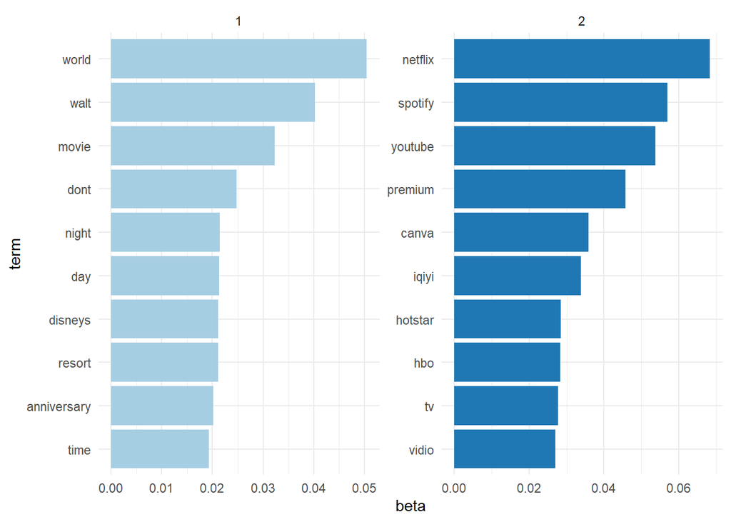

```r
#create a document term frequency based on how often words are
tweets_dtm <- tidy_disney %>%
  filter(word != "disney",
         word != "disney+",
         word != "bulan",
         word != "viu",
         word != "jual",
         word != "im") %>%
  count(id, word)%>%
  cast_dtm(
    document=id,
    term=word,
    value=n,
    weighting=tm::weightTf
    )

#to speed up processing let's remove those words that are VERY rare
tweets_dtm_trim<-tm::removeSparseTerms(tweets_dtm, sparse=.99)
rowTotals <- apply(tweets_dtm_trim, 1, sum) #Find the sum of words in each Document
tweets_dtm_trim <- tweets_dtm_trim[rowTotals> 0, ]

#LDA for 5 topics
tweets_lda<-LDA(tweets_dtm_trim, k=2, control=list(seed=1234))

tweet_topics<-tidy(tweets_lda, matrix="beta")

#let's look at them with 10 top words for each topic
tweet_top_terms <- tweet_topics %>%
  group_by(topic) %>%
  top_n(10, beta) %>%
  ungroup() %>%
  arrange(topic, -beta)

tweet_top_terms %>%
  mutate(term = reorder_within(term, beta, topic)) %>%
  ggplot(aes(term, beta, fill = factor(topic))) +
  geom_col(show.legend = FALSE) +
  facet_wrap(~ topic, scales = "free") +
  coord_flip() +
  scale_x_reordered() +
  theme_minimal() +
  theme(legend.title = element_blank()) +
  scale_fill_brewer(palette = "Paired")
```

—————————- Models —————————-

### Predicting favourites

**Insight** One of the possible models for prediction could be a model that predict location of person who published a tweet. However, due to large amount of NA values, this model would likely to be inaccurate. Out of 107 thousand tweets, only 2 thousands have accurate location data specified. Hence, we are going to look into favorites instead.

```r
disney %>%
  count(place_full_name, sort = TRUE) %>%
  head(5)
```

```
##   place_full_name      n
## 1            <NA> 105245
## 2    Florida, USA    271
## 3 Los Angeles, CA     73
## 4     Anaheim, CA     59
## 5   Illinois, USA     34
```

**Insight** Twitter has a function to favorite a tweet that you found interesting. Based on a number of “likes” we can tell if a tweet was seen by some people in their twitter feed or a tweet has not reached anyone and therefore was not noticed by any online audience. In Disney+ dataset there are 60 thousand tweets that haven’t received any likes and 46 thousand tweets that received at least one like.

```r
disney <- disney %>%
  mutate(liked = case_when(favorite_count > 0 ~ "Yes",
                           favorite_count == 0 ~ "No")) %>%
  mutate(liked = as.factor(liked))

disney %>%
  count(liked, sort = TRUE)
```

```
##   liked     n
## 1    No 60998
## 2   Yes 46372
```

```r
set.seed(2021)
data_split <- initial_split(disney, strata = liked)

train <- training(data_split)
test <- testing(data_split)
folds <- vfold_cv(train)

recipe <- recipe(liked ~ text, data = train) %>%
  step_tokenize(text) %>%
  step_tokenfilter(text, max_tokens = 1e3) %>%
  step_tfidf(text) %>%
  step_normalize(all_predictors())

spec <- naive_Bayes() %>%
  set_mode("classification") %>%
  set_engine("naivebayes")

nb_wf <- workflow() %>%
  add_recipe(recipe) %>%
  add_model(spec)

nb_rs <- fit_resamples(
  nb_wf,
  folds,
  control = control_resamples(save_pred = TRUE)
)

metr <- collect_metrics(nb_rs)
pred <- collect_predictions(nb_rs)

metr
```

```
## # A tibble: 2 x 6
##   .metric  .estimator  mean     n std_err .config
##   <chr>    <chr>      <dbl> <int>   <dbl> <chr>
## 1 accuracy binary     0.550    10 0.00400 Preprocessor1_Model1
## 2 roc_auc  binary     0.697    10 0.00158 Preprocessor1_Model1
```

**Insight** Based on the mae prediction, a confusion matrix was built. Here we can see exactly the correct and wrong predictions that were made and where the accuracy rate is coming from.

```r
expected_value <- pred$liked
predicted_value <- pred$.pred_class
example <- confusionMatrix(data=predicted_value, reference = expected_value)
example
```

```
## Confusion Matrix and Statistics
##
##           Reference
## Prediction    No   Yes
##        No   9811   280
##        Yes 35937 34499
##
##                Accuracy : 0.5503
##                  95% CI : (0.5468, 0.5537)
##     No Information Rate : 0.5681
##     P-Value [Acc > NIR] : 1
##
##                   Kappa : 0.1838
##
##  Mcnemar's Test P-Value : <2e-16
##
##             Sensitivity : 0.2145
##             Specificity : 0.9919
##          Pos Pred Value : 0.9723
##          Neg Pred Value : 0.4898
##              Prevalence : 0.5681
##          Detection Rate : 0.1218
##    Detection Prevalence : 0.1253
##       Balanced Accuracy : 0.6032
##
##        'Positive' Class : No
##
```

**Insight** Finally, a plot below showcasing the roc auc.

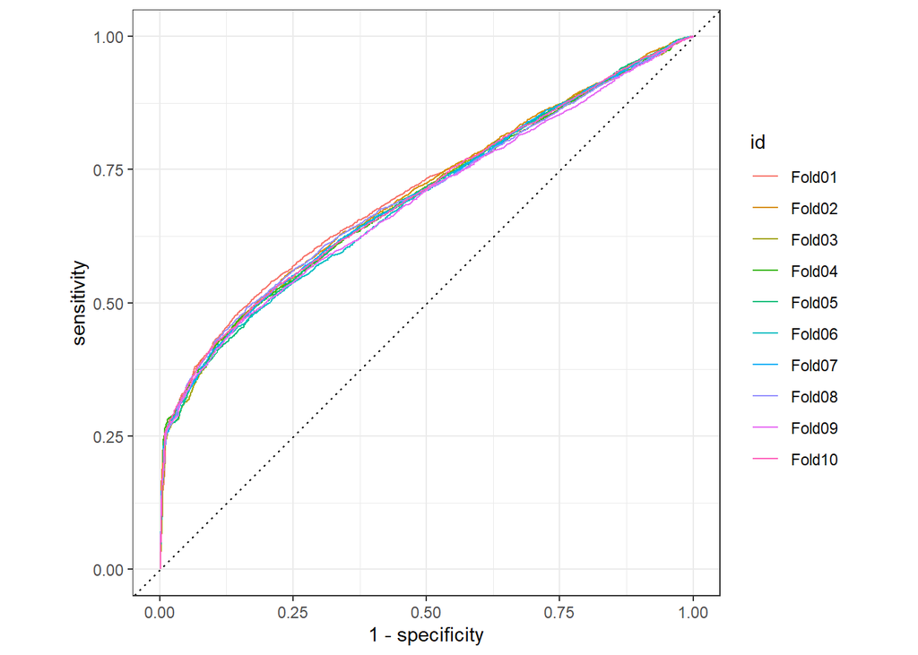

```r
pred %>%
  group_by(id) %>%
  roc_curve(truth = liked, .pred_No) %>%
  autoplot()
```

——————————— Conclusion ———————————

After considering all the previous insights and data analysis of Disney+, it can be said that digital and content marketing has the potential to increase revenue by more than 300 billion dollars since 70% of internet users tend to prefer digital content versus traditional advertisements as reported by Responsify digital marketing statistics.